# Chapter 4 Extended RLQ: finding the gradient

Chapter 3 ended in a dead end. Ordinary ordination found no spatial structure in composition, because it ranks axes by size and the gradient we wanted turned out to be axis 3 — smeared thinly, below a biomass axis and below a large axis of unstructured turnover.

The fix is to stop asking for the axis with the **most variance** and start asking for the axis with the **most covariance between two sides of the data**:

- what we know about each *microsample* — where it is, how deep it was sequenced, how diverse it is;
- what we know about each *genome* — its metabolic capacity and its position in the bacterial phylogeny.

An axis that scores highly on both is one where *position in the tissue* and *kind of bacterium* line up. That is precisely what a spatial gradient is, and neither noise nor biomass can fake it: there is no reason for a microsample’s DNA yield to correlate with what its bacteria can metabolise.

[output not shown]

[output not shown]

## 4.1 The five tables

Classical **RLQ** analysis links three tables: environmental variables of the sites (**R**), the community table (**L**), and species traits (**Q**). It finds the axes along which R and Q covary *through* L.

**Extended RLQ** (Pavoine et al. 2011) adds two more: the spatial arrangement of the sites (**S**) and the phylogeny of the species (**P**). Five tables, hence *ESLTP*.

| Table | In this dataset | Rows |
| --- | --- | --- |
| **E** environment | sequencing depth (≈ biomass), richness, distance to gut wall | microsamples |
| **S** space | Gabriel-graph neighbourhood structure | microsamples |
| **L** community | Hellinger-transformed genome abundances | microsamples × genomes |
| **T** traits | metabolic capacity (GIFT), ordinated | genomes |
| **P** phylogeny | patristic distances on the MAG tree | genomes |

### 4.1.1 Traits: what can each genome do?

Genome traits come from **GIFTs** (genome-inferred functional traits): for each genome, the completeness of every metabolic pathway it encodes, from its annotated genes. Nearly 300 traits per genome is too many to feed to RLQ directly, so we ordinate them first and keep the two main axes of metabolic variation.

```r
# genomes that survived filtering in either section
genomes_used <- union(colnames(caecum$comm_red), colnames(colon$comm_red))

gifts_used <- genome_gifts[rownames(genome_gifts) %in% genomes_used,
                           !grepl("^S0|^D04", colnames(genome_gifts)),
                           drop = FALSE]

dim(gifts_used)   # genomes x metabolic traits
```

```
[1]  92 292
```

```r
trait_pcoa <- ape::pcoa(dist(gifts_used))
round(trait_pcoa$values$Relative_eig[1:5], 3)
```

```
[1] 0.138 0.094 0.071 0.052 0.045
```

A shared trait ordination is used for both sections, so that an axis means the same thing in the caecum and in the colon.

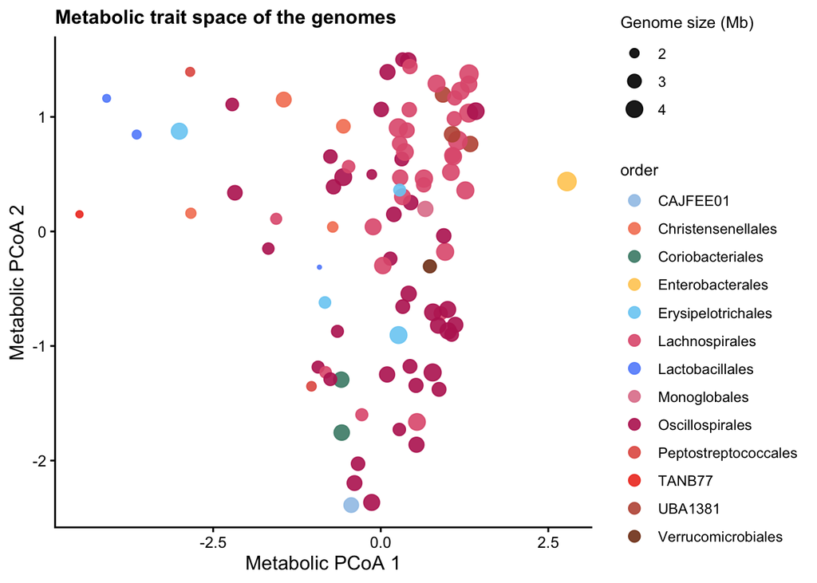

```r
as.data.frame(trait_pcoa$vectors[, 1:2]) %>%
  rownames_to_column("genome") %>%
  left_join(genome_metadata, by = "genome") %>%
  ggplot(aes(Axis.1, Axis.2, colour = order, size = length / 1e6)) +
  geom_point(alpha = 0.9) +
  scale_colour_manual(values = order_colors) +
  scale_size_continuous(range = c(0.8, 5), name = "Genome size (Mb)") +
  guides(colour = guide_legend(override.aes = list(size = 3))) +
  labs(x = "Metabolic PCoA 1", y = "Metabolic PCoA 2",
       title = "Metabolic trait space of the genomes")
```

Bacterial orders occupy distinct parts of trait space, and genome size varies across it — related bacteria have similar metabolic repertoires. This is why the phylogeny table **P** is worth including separately: it captures the part of “what kind of bacterium” that the trait table misses.

## 4.2 Running the analysis

```r
rlq_caecum <- spatial_rlq("G121eI117A", caecum$comm_red, caecum$metadata,
                          trait_pcoa, genome_tree)
rlq_colon  <- spatial_rlq("G121eO306A", colon$comm_red, colon$metadata,
                          trait_pcoa, genome_tree)

round(rlq_caecum$eig_prop[1:4], 3)   # share of co-inertia per axis
```

```
[1] 0.717 0.140 0.032 0.027
```

Two axes carry almost everything. Their *sign* is arbitrary — flipping an axis changes nothing but which end is drawn red — so we fix a convention that makes the caecum figures read left to right:

```r
rlq_caecum <- flip_rlq_axes(rlq_caecum, axes = c(1, 2))

caecum_sites   <- rlq_site_scores(rlq_caecum, caecum$metadata)
caecum_genomes <- rlq_genome_scores(rlq_caecum, genome_metadata)

colon_sites    <- rlq_site_scores(rlq_colon, colon$metadata)
colon_genomes  <- rlq_genome_scores(rlq_colon, genome_metadata)

head(caecum_sites %>% select(microsample, axis1, axis2, distance_host))
```

```
# A tibble: 6 × 4
  microsample   axis1   axis2 distance_host
  <chr>         <dbl>   <dbl>         <dbl>
1 M306710     -5.48    0.467           599.
2 M306711     -2.76    1.61            482.
3 M306712     -0.461  -0.0186          630.
4 M306714     -0.878   1.26            337.
5 M306715      0.256   0.109           492.
6 M306716     -0.0324  0.418           212.
```

Every microsample now has two coordinates in RLQ space, and so does every genome. That is the whole point of the method: microsamples and genomes are placed on the *same* axes.

## 4.3 What is each axis?

Never interpret an RLQ axis before checking what drives it. Correlate both axes against every microsample variable that went into **E**:

```r
axis_correlations <- function(sites, label) {
  vars <- list(
    "distance to gut wall"  = log(sites$distance_host),
    "sequencing depth"      = log(sites$after_filtering.total_bases),
    "richness"              = sites$richness
  )
  map_dfr(names(vars), function(v) {
    tibble(section = label, variable = v,
           axis1 = round(cor(sites$axis1, vars[[v]], method = "spearman"), 2),
           axis2 = round(cor(sites$axis2, vars[[v]], method = "spearman"), 2))
  })
}

bind_rows(axis_correlations(caecum_sites, "caecum"),
          axis_correlations(colon_sites,  "colon"))
```

```
# A tibble: 6 × 4
  section variable             axis1 axis2
  <chr>   <chr>                <dbl> <dbl>
1 caecum  distance to gut wall -0.11  0.48
2 caecum  sequencing depth      0.93 -0.3
3 caecum  richness              0.95 -0.37
4 colon   distance to gut wall -0.03  0.01
5 colon   sequencing depth      0.94  0.6
6 colon   richness              0.94  0.65
```

This table is the crux of the whole practical.

- **Axis 1** is sequencing depth and richness, in both sections (|ρ| ≈ 0.9). It is the **biomass axis**. Because libraries were pooled without normalisation (see the introduction), depth stands in for how much microbial biomass a microsample held, and axis 1 says that this is the dominant organising gradient of MSSM data. RLQ has separated it onto an axis of its own, which is what lets axis 2 be read cleanly.
- **Caecum axis 2** correlates with **distance to the gut wall** (ρ ≈ 0.5) and much more weakly with depth. This is the biological gradient.
- **Colon axis 2** is flat against distance to the gut wall (ρ ≈ 0.01) and still partly tracks depth and richness. This section has no detectable spatial gradient — an honest negative result, and a reminder that not every cryosection has one.

Is caecum axis 2 spatially autocorrelated, where PC1 was not?

```r
map_dfr(
  list(
    "caecum axis 1" = list(rlq_caecum, caecum_sites$axis1),
    "caecum axis 2" = list(rlq_caecum, caecum_sites$axis2),
    "colon axis 1"  = list(rlq_colon,  colon_sites$axis1),
    "colon axis 2"  = list(rlq_colon,  colon_sites$axis2)
  ),
  function(x) {
    tst <- moran.test(x[[2]], nb2listw(x[[1]]$nb), zero.policy = TRUE)
    tibble(morans_i = round(unname(tst$estimate[1]), 3),
           p_value  = signif(tst$p.value, 3))
  },
  .id = "axis"
)
```

```
# A tibble: 4 × 3
  axis          morans_i  p_value
  <chr>            <dbl>    <dbl>
1 caecum axis 1    0.097 0.0267
2 caecum axis 2    0.166 0.000683
3 colon axis 1     0.038 0.214
4 colon axis 2     0.021 0.312
```

Caecum axis 2 is significantly autocorrelated in space, and more strongly than anything PCA produced. The signal was there all along, in a *minor* axis of compositional variation — minor in size, but the only one organised both spatially and functionally.

Note also that axis 1, the biomass axis, is itself weakly autocorrelated (I = 0.10, p = 0.03), matching the patchiness of sequencing depth from Chapter 3. Biomass and community type are two different spatial patterns living in the same tissue, and RLQ has put them on separate axes.

## 4.4 The gradient on the tissue

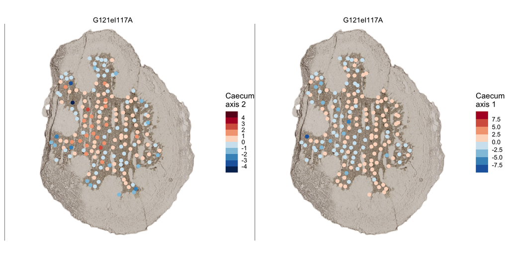

```r
plot_on_section("G121eI117A", caecum_sites, "axis2", "Caecum\naxis 2",
                pixel_coords) +
plot_on_section("G121eI117A", caecum_sites, "axis1", "Caecum\naxis 1",
                pixel_coords)
```

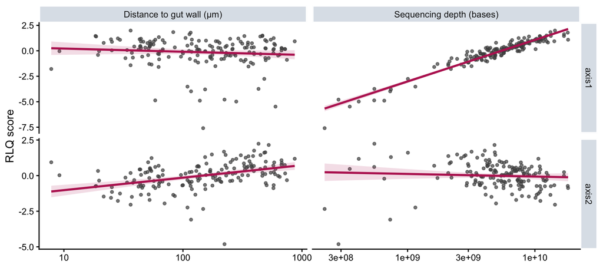

```r
caecum_sites %>%
  select(axis1, axis2, distance_host, after_filtering.total_bases) %>%
  pivot_longer(c(axis1, axis2), names_to = "axis", values_to = "score") %>%
  pivot_longer(c(distance_host, after_filtering.total_bases),
               names_to = "variable", values_to = "value") %>%
  mutate(variable = recode(variable,
                           distance_host = "Distance to gut wall (µm)",
                           after_filtering.total_bases = "Sequencing depth (bases)")) %>%
  ggplot(aes(x = value, y = score)) +
  geom_point(size = 1.2, alpha = 0.7, colour = "grey30") +
  geom_smooth(method = "lm", colour = "#ba2760", fill = "#ba2760", alpha = 0.15) +
  facet_grid(axis ~ variable, scales = "free") +
  scale_x_log10() +
  labs(x = NULL, y = "RLQ score")
```

Each axis responds to its own driver and is comparatively flat against the other’s. That separation is what RLQ was asked to find, and it is why the two can be interpreted independently: axis 1 is about *how much*, axis 2 about *which*.

## 4.5 Which bacteria sit at each end?

Because genomes live on the same axes, we can ask what distinguishes the two ends of the caecum gradient. First, taxonomically:

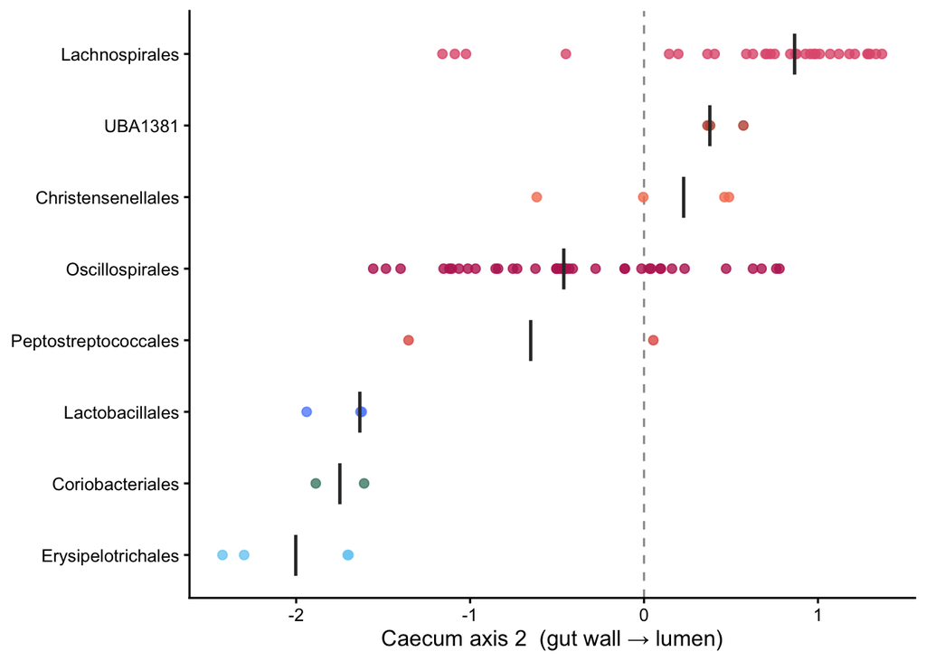

```r
caecum_genomes %>%
  add_count(order) %>%
  filter(n >= 2) %>%
  mutate(order = fct_reorder(order, axis2)) %>%
  ggplot(aes(x = axis2, y = order, colour = order)) +
  geom_vline(xintercept = 0, linetype = "dashed", colour = "grey60") +
  geom_point(size = 2, alpha = 0.8) +
  stat_summary(fun = median, geom = "point", shape = 124, size = 8,
               colour = "grey20") +
  scale_colour_manual(values = order_colors, guide = "none") +
  labs(x = "Caecum axis 2  (gut wall → lumen)", y = NULL)
```

Then by what those genomes can do. GIFT traits are grouped into broad functions, of which the degradation functions are the biologically interesting ones here:

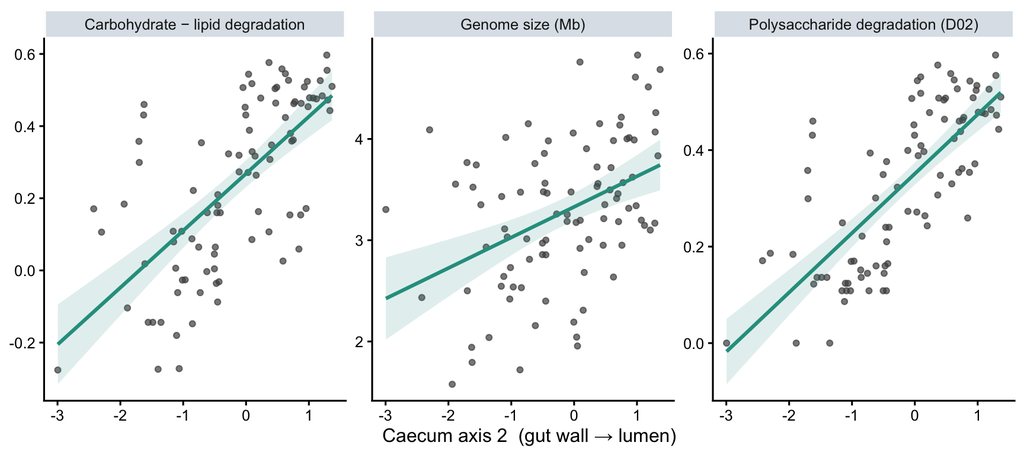

```r
gift_functions <- gifts_used %>%
  to.elements(GIFT_db_df) %>%
  to.functions(GIFT_db_df) %>%
  as.data.frame() %>%
  rownames_to_column("genome")

caecum_traits <- caecum_genomes %>%
  left_join(gift_functions, by = "genome") %>%
  mutate(genome_size_mb = length / 1e6,
         carb_minus_lipid = D02 - D01)

caecum_traits %>%
  select(axis2, `Genome size (Mb)` = genome_size_mb,
         `Polysaccharide degradation (D02)` = D02,
         `Carbohydrate − lipid degradation` = carb_minus_lipid) %>%
  pivot_longer(-axis2, names_to = "trait", values_to = "value") %>%
  ggplot(aes(x = axis2, y = value)) +
  geom_point(size = 1.4, alpha = 0.7, colour = "grey30") +
  geom_smooth(method = "lm", colour = "#2A9D8F", fill = "#2A9D8F",
              alpha = 0.15) +
  facet_wrap(~ trait, scales = "free_y") +
  labs(x = "Caecum axis 2  (gut wall → lumen)", y = NULL)
```

```r
tibble(
  trait = c("genome size", "polysaccharide degradation (D02)",
            "lipid degradation (D01)", "carbohydrate − lipid"),
  spearman_rho = c(
    cor(caecum_traits$axis2, caecum_traits$genome_size_mb, method = "spearman"),
    cor(caecum_traits$axis2, caecum_traits$D02, method = "spearman"),
    cor(caecum_traits$axis2, caecum_traits$D01, method = "spearman"),
    cor(caecum_traits$axis2, caecum_traits$carb_minus_lipid, method = "spearman")
  ) %>% round(2)
)
```

```
# A tibble: 4 × 2
  trait                            spearman_rho
  <chr>                                   <dbl>
1 genome size                              0.42
2 polysaccharide degradation (D02)         0.75
3 lipid degradation (D01)                 -0.33
4 carbohydrate − lipid                     0.68
```

## 4.6 The gradient on the phylogeny

Finally, colour the tree by each genome’s axis-2 score. If the gradient separates whole clades rather than scattered tips, it is evolutionarily conserved — bacteria inherit where they live.

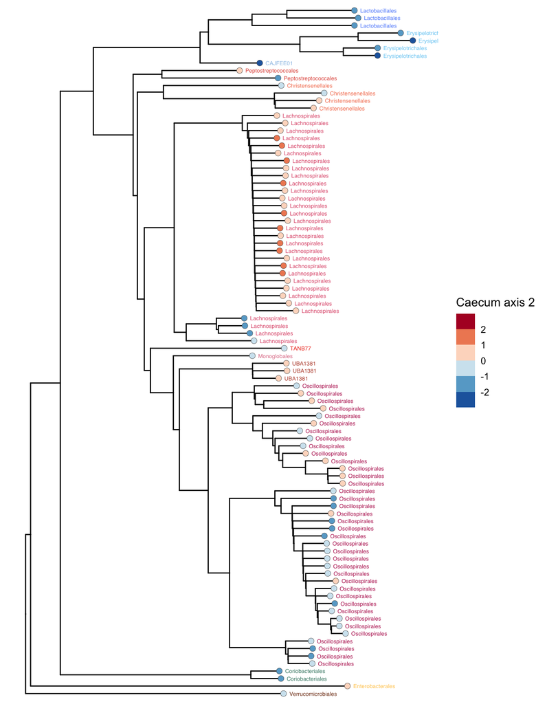

```r
caecum_tree <- keep.tip(genome_tree, caecum_genomes$genome)

plot_tree_gradient(caecum_tree, caecum_genomes, "axis2",
                   "Caecum axis 2", colours = order_colors)
```

```r
axis2_by_genome <- setNames(caecum_genomes$axis2, caecum_genomes$genome)

phytools::phylosig(caecum_tree, axis2_by_genome[caecum_tree$tip.label],
                   method = "K", test = TRUE)
```

```
Phylogenetic signal K : 1.52486
P-value (based on 1000 randomizations) : 0.001
```

Blomberg’s *K* above 1 with a significant p-value means closely related genomes occupy the same end of the gradient **more** than a random walk along the tree would produce. The spatial preference is phylogenetically conserved.

## 4.7 What the analysis found

Putting the three pieces together for caecum section G121eI117A:

|  | **Near the gut wall** | **Out in the lumen** |
| --- | --- | --- |
| Axis 2 score | low | high |
| Genome size | smaller | larger |
| Metabolism | relatively more lipid-oriented | more polysaccharide degradation |
| Taxa | Erysipelotrichales, Lactobacillales, Coriobacteriales | Lachnospirales, UBA1381 |

This is a biologically coherent story. Complex plant polysaccharides arrive in the lumen, and degrading them needs large gene repertoires — hence larger genomes with more carbohydrate-active machinery further from the wall. Close to the epithelium the substrates are host-derived instead, and the bacteria there are smaller and differently equipped.

**And it took the right method to see it.** The same data, analysed by PCA and PERMANOVA in Chapter 3, put this gradient on axis 3 and reported it as non-significant. It occupies a small share of total compositional variance — it was never going to be axis 1 of anything. RLQ found it because it looked for covariance between space and biology rather than for variance alone.

**And the protocol made it findable.** Because libraries were pooled without normalisation, biomass entered the analysis as a measured variable instead of hiding inside the composition. RLQ could give it axis 1 and hand back a clean axis 2. Under equimolar pooling the biomass differences would have been flattened away, and the variation they cause would still have been in the community table — unlabelled, unmodelled, and impossible to separate from the gradient.